# Tutorial R

2182028-Jorge Luis Sandoval Anaya

otro

May 06, 2021

# 1.Estuctura de control

Se utilizan para controlar el flujo del programas en una rutina o funcion.Estas estructuras permiten controlar,mediante una condicion,la ejecucion o no de una linea de codigo o conjunto de lineas. Las siguientes estructuras de control son las mas conocidas y usadas de R.

| Estructura de control | Descripcion |
| --- | --- |
| if | (si) es usado cuando deseamos que una operación se ejecute únicamente cuando una condición se cumple. |
| else | sirve para indicar instrucciones a realizar en caso de no cumplirse la condición del if. |
| for | nos permite ejecutar un bucle (loop), realizando una operación para cada elemento de un conjunto de datos. |
| while | Este es un tipo de bucle que ocurre mientras una condición es verdadera (TRUE). La operación se realiza hasta que se se llega a cumplir un criterio previamente establecido. |
| break | nos permite interrumpir un bucle |
| next | nos deja avanzar a la siguiente iteración del bucle. |
| repeat | Este es un bucle que se llevará a cabo el número de veces que especifiquemos. |

# 2. Listas y vectores

Un vector es la estructura de datos más sencilla en R. Un vector es una colección de uno o más datos del mismo tipo,es decir es una estructura homogenea.

### 2.1 Creacion de vectores

Para crear un vector debemos usar la funcion c() (combinar) y darle como argumento los elementos que deseamos combinar en el vector,separados por comas.

### Ejemplo

```r
#Vector numerico
c(100,3456,4578,899)
```

```
## [1]  100 3456 4578  899
```

```r
#vector de texto
c("Estadistica","Moda","Mediana","Media")
```

```
## [1] "Estadistica" "Moda"        "Mediana"     "Media"
```

Si se desea agregar un dato a un vector ya existente,lo podemos hacer combinando dicho vector con el nuevo dato.

```r
vector_ejemplo <- c(1,2,3,4,5,6)
vector_ejemplo <- c(vector_ejemplo,7)
vector_ejemplo
```

```
## [1] 1 2 3 4 5 6 7
```

Asi mismo se puede crear un vector con la combinacion de dos ya existentes.

```r
Ejemplo1 <- c(100,200,300)
Ejemplo2 <- c(400,500,600)
Ejemplo3 <- c(Ejemplo1,Ejemplo2)
Ejemplo3
```

```
## [1] 100 200 300 400 500 600
```

Al intentar realizar la combinacion de vectores que tienen tipos de datos diferentes,R realiza coercion automaticamente dando origen a un vector del tipo de dato mas flexible segun las reglas de coercion.

```r
class(Ejemplo3)
```

```
## [1] "numeric"
```

ahora se agregara un dato de tipo de cadena de texto y se vera en uso las reglas de coercion.

```r
class(c(Ejemplo3,"Estadistica"))
```

```
## [1] "character"
```

Tambien pordemos crear vectores con secuencias numericas utilizando `:`. En el lado izquierdo de los dos puntos se coloca el numero(decimal,negativo o positivo) de inicio de dicha secuencia y en el lado derecho escribimos donde finalizara.

```r
#secuencia inicia en 10 y va hasta a 3
c(10:34)
```

```
##  [1] 10 11 12 13 14 15 16 17 18 19 20 21 22 23 24 25 26 27 28 29 30 31 32 33 34
```

En R existen operaciones aritmetica y relacionales que podemos aplicar a cada dato de un vector,a este proceso se le llama vectorizacion.

```r
#suma
Ejemplo3+5
```

```
## [1] 105 205 305 405 505 605
```

```r
#multiplicacion
Ejemplo3*8
```

```
## [1]  800 1600 2400 3200 4000 4800
```

```r
#divicion
Ejemplo3/2
```

```
## [1]  50 100 150 200 250 300
```

Al aplicar operaciones relacionales se obtiene un vector logico para cada uno de los elementos comparados

```r
#numeros mayor de 200
Ejemplo3>200
```

```
## [1] FALSE FALSE  TRUE  TRUE  TRUE  TRUE
```

```r
#numeros menor de 200
Ejemplo3<200
```

```
## [1]  TRUE FALSE FALSE FALSE FALSE FALSE
```

```r
#numeros igual a 200
Ejemplo3==200
```

```
## [1] FALSE  TRUE FALSE FALSE FALSE FALSE
```

### 2.2 Listas

Las listas, al igual que los vectores, son estructuras de datos unidimensionales, sólo tienen largo, pero a diferencia de los vectores cada uno de sus elementos puede ser de diferente tipo o incluso de diferente clase, por lo que son estructuras heterogéneas.

### 2.21 Creacion de listas

Para crear una lista es necesario usar la funcion `list()`,la cual nos pidira como argumentos los elemtos que deseamos incluir en la nueva lista.Para esta estructura, no importan las dimensiones o largo de los elementos que queramos incluir en ella.

### Ejemplo

```r
#vector de 1 a 10
vector <- 1:10
#matriz
matriz <- matrix(1:6, nrow=3)
lista <- list("vector"=vector,"matriz"=matriz)
lista
```

```
## $vector
##  [1]  1  2  3  4  5  6  7  8  9 10
##
## $matriz
##      [,1] [,2]
## [1,]    1    4
## [2,]    2    5
## [3,]    3    6
```

# 3.Funciones

Para crear funciones en R debemos utilizar el comando `function()` con el cual se creara objetos de tipo function de la siguiente manera.

```
f <- function(<argumentos>)
{
    ## codigo de la funcion
}
```

Cuando le asignamos una funcion a un nombre decimos que hemos definido una funcion.

Una vez que la función tiene nombre, podemos llamarla usando su nombre, al igua lque con las funciones por defecto de R.

```r
f <- function(){
  cat("Hola mundo")

}
#llamando la funcion f
f()
```

```
## Hola mundo
```

Toda funcion esta compuesta de 3 partes las cuales veremos a continuacion.

| Parte | Descripcion |
| --- | --- |
| Nombre | Nos permite ejecutar y hacer referencia sobre una funcion |
| Argumentos | Son la variables que necesitan las funciones para poder realizar sus operaciones |
| Cuerpo | Contiene todas las operaciones que se ejecutaran cuando la funcion sea llamada |

# 4. Distribuciones de probabilidad en R

A cada nombre de probabilidad dado por R se le agrega un prefijo `d` para obtener la funcion de densidad,`p` para la funcion de distribucion acumulada y `q` para la funcion cuantil.La sintaxis de lo anterior es la siguiente.

```
 dname(x,.....) #evalua la funcion de densidad
 pname(x,.....) #evalua la funcion de distribucion
 qname(x,.....) #evalua la funcion cuantil
```

## Distribucion Beta

### Funcion de densidad

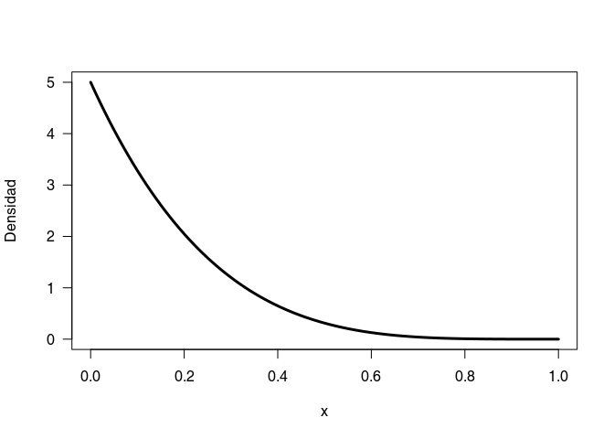

```r
 curve(dbeta(x, shape1=1, shape2=5), lwd=3, las=1,
      ylab='Densidad')
```

### Funcion de distribucion acumulada

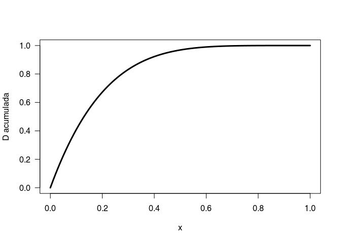

```r
curve(pbeta(x, shape1=1, shape2=5),lwd=3,las=1,
      ylab='D acumulada')
```

### Funcion cuantil

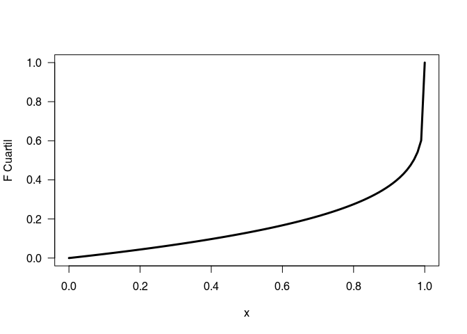

```r
curve(qbeta(x, shape1=1, shape2=5),lwd=3,las=1,
      ylab='F Cuartil')
```

## Distribucion normal

### Funcion de densidad

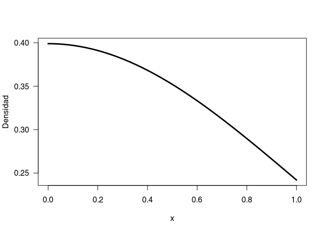

```r
 curve(dnorm(x, mean = 0, sd=1), lwd=3, las=1,
      ylab='Densidad')
```

### Funcion de distribucion acumulada

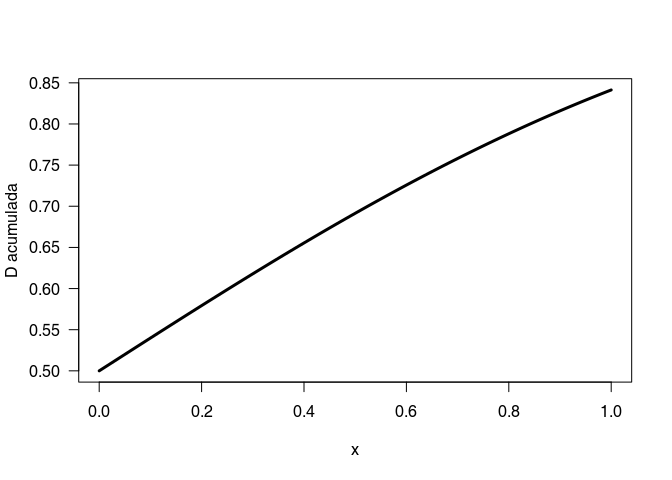

```r
curve(pnorm(x, mean = 0, sd=1),lwd=3,las=1,
      ylab='D acumulada')
```

### Funcion cuantil

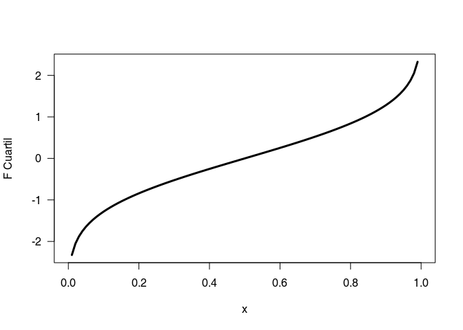

```r
curve(qnorm(x, mean = 0, sd=1),lwd=3,las=1,
      ylab='F Cuartil')
```

## Distribucion binomial

### Funcion de densidad

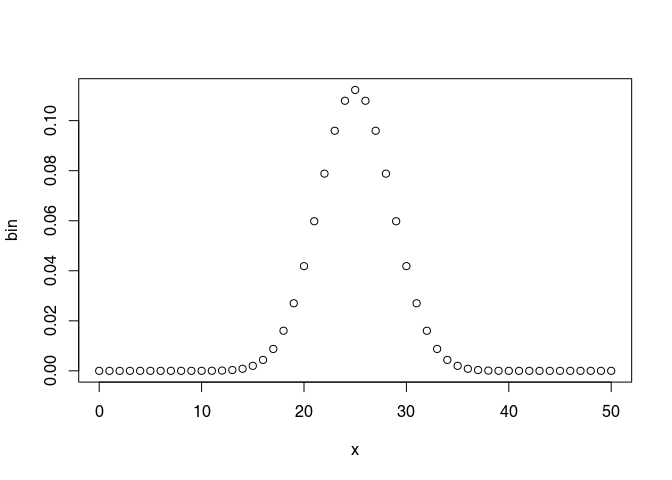

```r
x <- seq(0,50,by=1)#secuencia de 50 numeros ordenados
bin <- dbinom(x,size=50,prob=0.5)
plot(x,bin)
```